# Solution tutorial single-cell RNA-seq: COVID-19 and B cells

Author

Affiliation

Lieven Clement

Ghent University

This is a solution of Exercise 2 of the single-cell RNA-seq tutorial. Several questions have more than one good answer: the code below is one possible analysis.

```r
library(tidyverse)
library(SingleCellExperiment)
library(scrapper)
library(omicsGMF)
library(edgeR)
library(stageR)
library(patchwork)

plotDims <- function(dims, color, colorName, title) {
  # plot the cells in a random order, so that no group hides another
  tibble(dim1 = dims[, 1], dim2 = dims[, 2], color = color) |>
    slice_sample(prop = 1) |>
    ggplot(aes(dim1, dim2, color = color)) +
    geom_point(size = 0.3) +
    labs(color = colorName, title = title) +
    theme_bw() +
    theme(legend.text = element_text(size = 6), legend.key.size = unit(0.3, "cm"))
}
```

```r
url <- "https://github.com/statOmics/SGA/releases/download/scrnaseq-v1/"
dir.create("scrnaseqData", showWarnings = FALSE)
if (!file.exists("scrnaseqData/covid_bcells.rds")) {
  download.file(paste0(url, "covid_bcells.rds"), "scrnaseqData/covid_bcells.rds", mode = "wb")
}
covid <- readRDS("scrnaseqData/covid_bcells.rds")
covid
```

```
class: SingleCellExperiment
dim: 17423 51735
metadata(3): source selection reference
assays(1): counts
rownames(17423): A1BG A1BG-AS1 ... ZYX ZZEF1
rowData names(0):
colnames(51735): AAACCTGCAGATTGCT-MH9179824_3
  AAAGATGAGCTGAACG-MH9179824_3 ... GTAGGCCCACATCTTT-MH9143425_9
  GTTCATTAGTCTTGCA-MH9143425_9
colData names(6): donor site ... status celltype
reducedDimNames(0):
mainExpName: NULL
altExpNames(0):
```

# Design

## 1. Donors, sites and disease status

```r
donors <- as_tibble(as.data.frame(colData(covid))) |>
  dplyr::select(donor, site, sex, age, status) |>
  distinct()
nrow(donors)
```

```
[1] 100
```

```r
table(covid$celltype)
```

```
                naive B cell              immature B cell
                       36535                         4148
    unswitched memory B cell class switched memory B cell
                        2638                         6107
                      B cell
                        2307
```

```r
table(site = donors$site, status = donors$status)
```

```
           status
site        Healthy Asymptomatic Mild Moderate Severe Critical
  Cambridge      11            8    9       10      3        5
  Ncl            12            1   11       16      7        7
```

- There are 51735 cells of 100 donors and 5 B-cell types.
- The experimental unit is the donor: the disease status, the site, the sex and the age are properties of the donor, not of the cell. The cells of one donor are pseudoreplicates.
- The design is unbalanced: the groups differ in size, and the sites have different numbers of donors per disease status.
- The severe (10) and critical (12) groups and the asymptomatic patients (9) contain few donors.
- The asymptomatic patients are almost confounded with the site: 8 of the 9 asymptomatic patients come from Cambridge. The comparison of the asymptomatic patients with the healthy donors relies on the assumption that the site effect is the same for all groups, and the site effect is mainly estimated from the other groups.

```r
table(sex = donors$sex, status = donors$status)
```

```
        status
sex      Healthy Asymptomatic Mild Moderate Severe Critical
  female      12            4   13        8      5        6
  male        11            5    7       18      5        6
```

```r
table(age = donors$age, status = donors$status)
```

```
         status
age       Healthy Asymptomatic Mild Moderate Severe Critical
  third         4            1    0        1      0        0
  fourth        5            1    3        3      0        0
  fifth         3            4    4        4      2        4
  sixth         6            1    4        8      4        2
  seventh       4            0    5        6      1        2
  eighth        1            2    1        1      2        4
  ninth         0            0    3        3      1        0
```

The sex and the age are also not balanced: the moderate group contains more men, and the critical patients are older than the healthy donors.

## 2. Cells per donor and cell type

```r
cellsPerDonor <- table(donor = droplevels(covid$donor), celltype = covid$celltype)
summary(as.data.frame.matrix(cellsPerDonor))
```

```
  naive B cell    immature B cell  unswitched memory B cell
 Min.   :  15.0   Min.   :  1.00   Min.   :  1.00
 1st Qu.: 118.5   1st Qu.: 15.00   1st Qu.:  8.75
 Median : 255.5   Median : 25.50   Median : 17.50
 Mean   : 365.4   Mean   : 41.48   Mean   : 26.38
 3rd Qu.: 505.5   3rd Qu.: 56.00   3rd Qu.: 35.50
 Max.   :2066.0   Max.   :239.00   Max.   :176.00
 class switched memory B cell     B cell
 Min.   :  4.00               Min.   :  0.00
 1st Qu.: 21.00               1st Qu.:  3.75
 Median : 45.50               Median : 14.00
 Mean   : 61.07               Mean   : 23.07
 3rd Qu.: 73.25               3rd Qu.: 28.00
 Max.   :433.00               Max.   :233.00
```

```r
colSums(cellsPerDonor >= 20)
```

```
                naive B cell              immature B cell
                          99                           69
    unswitched memory B cell class switched memory B cell
                          46                           76
                      B cell
                          39
```

The naive B cells are by far the most abundant cell type: almost all donors have more than 20 naive B cells. The immature, unswitched memory and the other B cells are rare: many donors have fewer than 20 of these cells.

# Exploration

## 3. Naive B cells

```r
naive <- covid[, covid$celltype == "naive B cell"]
set.seed(1234)
naive <- naive[, sample(ncol(naive), 4000)]
naive <- naive[rowSums(counts(naive)) > 0, ]
naive$sum <- colSums(counts(naive))
naive <- normalizeRnaCounts.se(naive, size.factors = naive$sum)
naive <- chooseRnaHvgs.se(naive)
naive <- runPca.se(naive, features = rowData(naive)$hvg)
set.seed(1234)
naive <- runAllNeighborSteps.se(naive, tsne.output.name = NULL, cluster.output.name = NULL)
```

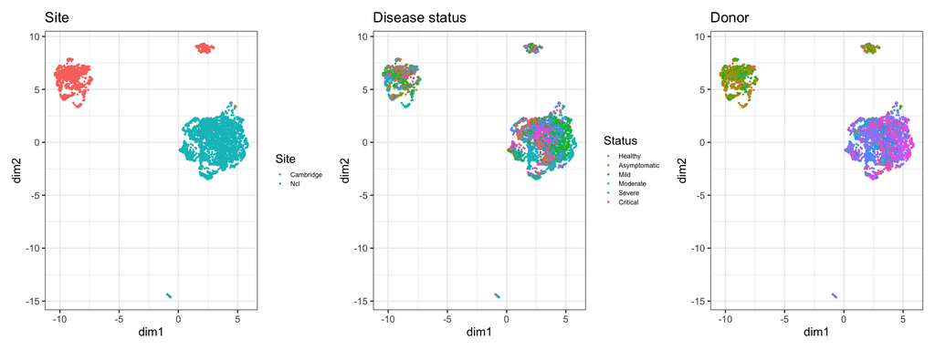

```r
umap <- reducedDim(naive, "UMAP")
plotDims(umap, naive$site, "Site", "Site") +
  plotDims(umap, naive$status, "Status", "Disease status") +
  plotDims(umap, naive$donor, "Donor", "Donor") +
  theme(legend.position = "none")
```

```r
pcs <- reducedDim(naive, "PCA")
explained <- function(variable) {
  sapply(1:5, function(k) summary(lm(pcs[, k] ~ variable))$r.squared)
}
round(rbind(site = explained(naive$site),
            status = explained(naive$status),
            donor = explained(naive$donor)), 2)
```

```
       [,1] [,2] [,3] [,4] [,5]
site   0.56 0.26 0.03 0.02 0.00
status 0.11 0.10 0.09 0.03 0.05
donor  0.65 0.48 0.28 0.16 0.23
```

- The site dominates: the cells of the two sites are separated in the UMAP, and the site explains a large proportion of the variance of PC1.
- The disease status explains little of the variance of the first PCs.
- The donor explains more variance than the site, because the donor is nested in the site: the donor effect contains the site effect, and also the disease status, sex and age of the donor and its sample processing.

## 4. Site effect and library size

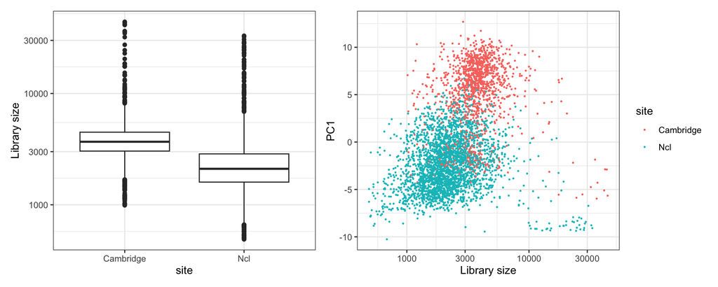

```r
p1 <- tibble(site = naive$site, sum = naive$sum) |>
  ggplot(aes(site, sum)) +
  geom_boxplot() +
  scale_y_log10() +
  labs(y = "Library size") +
  theme_bw()
p2 <- tibble(PC1 = pcs[, 1], sum = naive$sum, site = naive$site) |>
  ggplot(aes(sum, PC1, color = site)) +
  geom_point(size = 0.3) +
  scale_x_log10() +
  labs(x = "Library size") +
  theme_bw()
p1 + p2
```

```r
logSum <- log(naive$sum)
anova(lm(pcs[, 1] ~ logSum + naive$site))
```

```
Analysis of Variance Table

Response: pcs[, 1]
             Df Sum Sq Mean Sq F value    Pr(>F)
logSum        1  11771   11771  1233.0 < 2.2e-16 ***
naive$site    1  38103   38103  3991.2 < 2.2e-16 ***
Residuals  3997  38158      10
---
Signif. codes:  0 '***' 0.001 '**' 0.01 '*' 0.05 '.' 0.1 ' ' 1
```

- The cells of Cambridge have larger libraries than those of Newcastle.
- PC1 is associated with the library size, also within each site: the normalisation and the log-transformation do not remove the effect of the sequencing depth completely.
- After a linear correction for the log library size, the site still explains a large part of the variance of PC1. This does not prove that the site effect is more than a difference in depth: the effect of the depth on the log-transformed counts is not linear, because of the pseudo-count and the many small counts.
- Exercise 5 shows that the factors of a GMF, which models the library size on the count scale with an intercept for each cell, are hardly associated with the site. So most of the site effect in the PCA is an artefact of the different sequencing depth in combination with the log-transformation.

## 5. GMF with and without correction for the site

```r
set.seed(1234)
sub <- naive[, sample(ncol(naive), 2000)]
top1000 <- rownames(naive)[order(rowData(naive)$residuals, decreasing = TRUE)[1:1000]]
sub <- sub[top1000, ]
set.seed(1234)
sub <- runGMF(sub, family = poisson(), ncomponents = 10)
X <- model.matrix(~ site, data = colData(sub))
set.seed(1234)
sub <- runGMF(sub, family = poisson(), ncomponents = 10,
              X = X, name = "GMF_site")
set.seed(1234)
sub <- runAllNeighborSteps.se(sub, reddim.type = "GMF", umap.output.name = "UMAP_GMF",
                              tsne.output.name = NULL, cluster.output.name = NULL)
set.seed(1234)
sub <- runAllNeighborSteps.se(sub, reddim.type = "GMF_site", umap.output.name = "UMAP_GMF_site",
                              tsne.output.name = NULL, cluster.output.name = NULL)
```

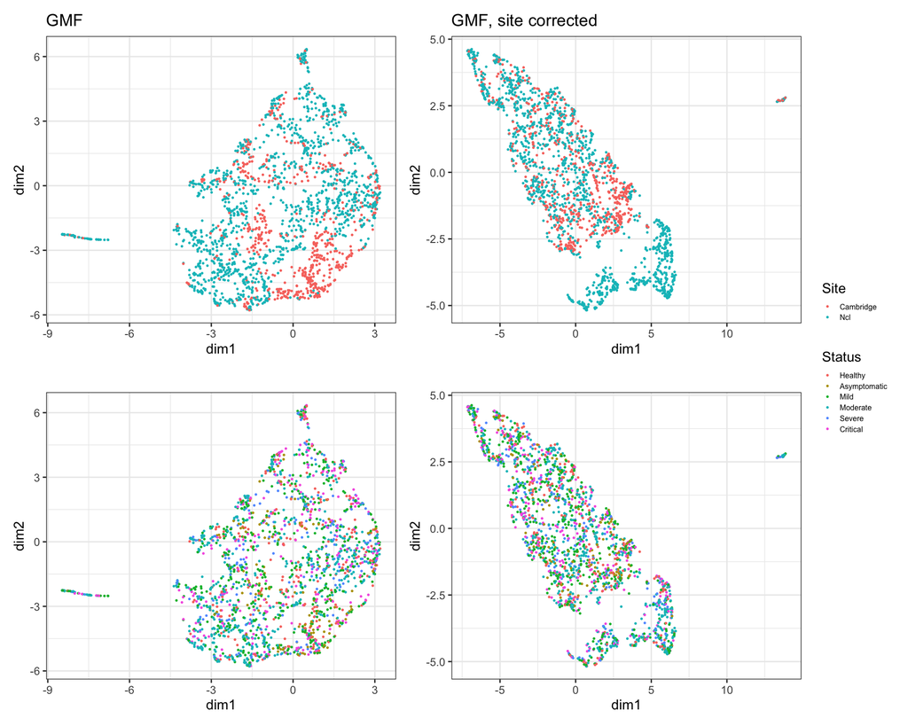

```r
(plotDims(reducedDim(sub, "UMAP_GMF"), sub$site, "Site", "GMF") +
   plotDims(reducedDim(sub, "UMAP_GMF_site"), sub$site, "Site", "GMF, site corrected")) /
  (plotDims(reducedDim(sub, "UMAP_GMF"), sub$status, "Status", "") +
     plotDims(reducedDim(sub, "UMAP_GMF_site"), sub$status, "Status", "")) +
  plot_layout(guides = "collect")
```

```r
sub <- runPca.se(sub, features = rownames(sub), number = 10)
r2 <- function(dims, variable) sapply(1:5, function(k) summary(lm(dims[, k] ~ variable))$r.squared)
round(rbind(PCA = r2(reducedDim(sub, "PCA"), sub$site),
            GMF = r2(reducedDim(sub, "GMF"), sub$site),
            GMF_site = r2(reducedDim(sub, "GMF_site"), sub$site)), 3)
```

```
          [,1]  [,2]  [,3]  [,4]  [,5]
PCA      0.559 0.273 0.006 0.011 0.066
GMF      0.000 0.028 0.050 0.000 0.038
GMF_site 0.000 0.002 0.000 0.027 0.003
```

- The model of the GMF with correction is
  $$y_{gc} \sim \text{Poisson}(\mu_{gc}), \quad
  \log \mu_{gc} = \beta_{g0} + \beta_{g1} x_{c,\text{Ncl}} + \alpha_c + \sum_{k=1}^{10} u_{ck} v_{gk},$$
  with $\alpha_c$ the intercept of cell $c$, which captures its library size.
- The site effect is much smaller in the GMF than in the PCA, also without correction: the cell intercept of the GMF models the library size on the count scale, which removes most of the technical effect of the sequencing depth. The correction for the site removes the remaining association.
- We can correct for the site because the site is not confounded with the disease status: both sites contain healthy donors and patients of all groups. In the Kang data, all stimulated cells were sequenced in one run and all control cells in another run: correcting for the run would also remove the effect of the stimulation.

# Differential expression

## 6. Pseudobulk samples

```r
pb <- aggregateAcrossCells.se(covid, factors = list(celltype = covid$celltype, donor = covid$donor),
                              counts.name = "ncells")
pb$site <- covid$site[match(pb$donor, covid$donor)]
pb$sex <- covid$sex[match(pb$donor, covid$donor)]
pb$age <- covid$age[match(pb$donor, covid$donor)]
pb$status <- covid$status[match(pb$donor, covid$donor)]
table(pb$ncells >= 20, pb$celltype)
```

```
        naive B cell immature B cell unswitched memory B cell
  FALSE            1              31                       54
  TRUE            99              69                       46

        class switched memory B cell B cell
  FALSE                           24     60
  TRUE                            76     39
```

```r
pb <- pb[, pb$ncells >= 20]
```

A pseudobulk sample of a few cells has a small library and a large variability, because the expression of a few cells is more variable than the average of many cells. The negative binomial / QL model assumes that the dispersion is the same for all samples, which does not hold when the samples are built from very different numbers of cells. Pseudobulk samples of few cells also give little information on the donor.

## 7. Model for the naive B cells

```r
yNaive <- DGEList(assay(pb, "sums")[, pb$celltype == "naive B cell"],
                  samples = as.data.frame(colData(pb)[pb$celltype == "naive B cell",
                                                      c("donor", "site", "sex", "age", "status", "ncells")]))
yNaive$samples$status <- relevel(droplevels(yNaive$samples$status), ref = "Healthy")
design <- model.matrix(~ site + sex + status, data = yNaive$samples)
colnames(design)
```

```
[1] "(Intercept)"        "siteNcl"            "sexmale"
[4] "statusAsymptomatic" "statusMild"         "statusModerate"
[7] "statusSevere"       "statusCritical"
```

```r
yNaive <- yNaive[filterByExpr(yNaive, design = design), , keep.lib.sizes = FALSE]
yNaive <- normLibSizes(yNaive)
fitNaive <- glmQLFit(yNaive, design)
```

We propose the model
$$y_{gi} \sim NB(\mu_{gi}, \phi_g), \quad
\log \mu_{gi} = \beta_{g0} + \beta_{g,\text{Ncl}} x_{i,\text{Ncl}} + \beta_{g,\text{male}} x_{i,\text{male}} + \sum_{s} \beta_{g,s} x_{i,s} + \log N_i,$$
with $y_{gi}$ the pseudobulk count of gene $g$ in donor $i$, $N_i$ the effective library size and $s$ the disease groups asymptomatic, mild, moderate, severe and critical.

- The site is a known batch (blocking variable): it is not confounded with the disease status, and it has a strong effect on the expression (exercise 3).
- The sex is unbalanced between the groups and has an effect on the expression of genes on the sex chromosomes.
- We do not include the donor: there is one pseudobulk sample per donor, so the donor is the experimental unit and its variability is part of the residual variability.
- Interpretation: $\beta_{g0}$ is the log expression of a healthy woman of Cambridge. $\beta_{g,\text{Ncl}}$ is the log fold change between Newcastle and Cambridge, $\beta_{g,\text{male}}$ between men and women, and $\beta_{g,s}$ is the log fold change between disease group $s$ and the healthy donors, for donors of the same site and sex.

The age is a potential confounder: the critical patients are older than the healthy donors. The age is given in decades and would cost 6 parameters as a factor (with fewer than 100 donors), or 1 as a numeric variable (with the assumption of a linear trend in the decades). We refit the model with a linear effect of the age as a sensitivity analysis:

```r
yNaive$samples$ageNum <- as.integer(yNaive$samples$age)
designAge <- model.matrix(~ site + sex + ageNum + status, data = yNaive$samples)
fitAge <- glmQLFit(yNaive, designAge)
summary(decideTests(glmQLFTest(fitAge, coef = "ageNum")))
```

```
       ageNum
Down        2
NotSig   8803
Up         23
```

## 8. Contrasts

```r
L <- cbind(
  Asymptomatic = c(0, 0, 0, 1, 0, 0, 0, 0),
  Mild = c(0, 0, 0, 0, 1, 0, 0, 0),
  Moderate = c(0, 0, 0, 0, 0, 1, 0, 0),
  Severe = c(0, 0, 0, 0, 0, 0, 1, 0),
  Critical = c(0, 0, 0, 0, 0, 0, 0, 1),
  Average = c(0, 0, 0, 1, 1, 1, 1, 1) / 5
)
rownames(L) <- colnames(design)
L
```

```
                   Asymptomatic Mild Moderate Severe Critical Average
(Intercept)                   0    0        0      0        0     0.0
siteNcl                       0    0        0      0        0     0.0
sexmale                       0    0        0      0        0     0.0
statusAsymptomatic            1    0        0      0        0     0.2
statusMild                    0    1        0      0        0     0.2
statusModerate                0    0        1      0        0     0.2
statusSevere                  0    0        0      1        0     0.2
statusCritical                0    0        0      0        1     0.2
```

```r
tests <- apply(L, 2, function(contrast) glmQLFTest(fitNaive, contrast = contrast), simplify = FALSE)
nDE <- sapply(tests, function(test) summary(decideTests(test))[, 1])
nDE
```

```
       Asymptomatic Mild Moderate Severe Critical Average
Down              0  105      857    573      408     712
NotSig         8825 8518     6387   7034     7399    6849
Up                3  205     1584   1221     1021    1267
```

```r
table(yNaive$samples$status)
```

```
     Healthy Asymptomatic         Mild     Moderate       Severe     Critical
          23            9           20           25           10           12
```

```r
testsAge <- apply(rbind(L[1:3, ], ageNum = 0, L[4:8, ]), 2,
                  function(contrast) glmQLFTest(fitAge, contrast = contrast), simplify = FALSE)
sapply(testsAge, function(test) summary(decideTests(test))[, 1])
```

```
       Asymptomatic Mild Moderate Severe Critical Average
Down              0   42      726    374      281     538
NotSig         8826 8685     6686   7452     7720    7240
Up                2  101     1416   1002      827    1050
```

- The asymptomatic patients hardly differ from the healthy donors, the mild patients a little, and the moderate, severe and critical patients strongly.
- The moderate group has the most DE genes: it is the largest group (25 donors). The severe and critical groups have fewer donors and less power, although their effects are probably at least as large.
- The asymptomatic group is small, and its comparison with the healthy donors relies on the site effect estimated from the other groups.
- The average contrast pools all patients, but it averages effects that differ between the groups and its interpretation is not clear-cut.
- With the age in the model, only a few genes have a significant age effect, but the numbers of DE genes decrease, mostly for the severe and critical patients, who are older than the healthy donors. Part of the differences with the healthy donors can be explained by the age. Whether we should correct for the age depends on the question: the age is a risk factor for a severe disease, so the age is not a pure confounder.

## 9. Omnibus test

```r
omnibus <- glmQLFTest(fitNaive, coef = grep("status", colnames(design)))
summary(decideTests(omnibus))
```

```
       statusCritical-statusSevere-statusModerate-statusMild-statusAsymptomatic
NotSig                                                                     6691
Sig                                                                        2137
```

```r
omnibus$df.test[1]
```

```
[1] 5
```

The omnibus test has 5 degrees of freedom: it tests that the 5 parameters of the disease groups are all zero, i.e. that the expression is the same in all 6 groups. This test can be used as the screening stage of a stage-wise analysis, with the 5 comparisons with the healthy donors in the confirmation stage.

## 10. Top genes critical vs healthy

```r
topTags(tests$Critical, n = 20)$table |>
  dplyr::select(logFC, logCPM, F, FDR) |>
  knitr::kable(digits = 3)
```

|  | logFC | logCPM | F | FDR |
| --- | --- | --- | --- | --- |
| IGHV2-70D | 6.306 | 5.907 | 61.341 | 0 |
| PSME2 | 1.320 | 8.250 | 55.790 | 0 |
| IGHV1-45 | 6.443 | 4.400 | 50.618 | 0 |
| MZB1 | 2.719 | 8.512 | 50.776 | 0 |
| SDF2L1 | 2.846 | 6.623 | 50.683 | 0 |
| RRM2 | 5.737 | 4.775 | 47.654 | 0 |
| PRDX1 | 1.290 | 7.314 | 49.121 | 0 |
| SRPRB | 1.884 | 5.310 | 48.851 | 0 |
| PSMD8 | 0.822 | 6.986 | 47.729 | 0 |
| PCLAF | 4.434 | 3.708 | 44.252 | 0 |
| MYDGF | 2.104 | 7.290 | 45.887 | 0 |
| GINS2 | 3.657 | 3.143 | 43.363 | 0 |
| PSAT1 | 4.386 | 2.711 | 43.838 | 0 |
| BUB1 | 3.760 | 3.221 | 42.585 | 0 |
| XBP1 | 2.228 | 6.726 | 44.970 | 0 |
| FKBP11 | 2.830 | 6.494 | 44.713 | 0 |
| CDC20 | 5.514 | 3.547 | 43.368 | 0 |
| IGHG1 | 4.650 | 9.242 | 42.628 | 0 |
| TMEM208 | 1.527 | 5.777 | 42.558 | 0 |
| TRBC2 | -0.816 | 7.684 | 42.338 | 0 |

```r
isg <- c("IFI27", "IFI44L", "IFI6", "ISG15", "MX1", "XAF1", "IFIT3", "PSME2")
topTags(tests$Critical, n = Inf)$table[intersect(isg, rownames(yNaive)), c("logFC", "FDR")] |>
  knitr::kable(digits = 3)
```

|  | logFC | FDR |
| --- | --- | --- |
| IFI27 | 3.919 | 0.002 |
| IFI44L | 0.969 | 0.348 |
| IFI6 | 1.047 | 0.130 |
| ISG15 | 0.720 | 0.325 |
| MX1 | 0.612 | 0.312 |
| XAF1 | 0.187 | 0.815 |
| IFIT3 | 0.601 | 0.678 |
| PSME2 | 1.320 | 0.000 |

- The top genes are mainly not interferon-stimulated genes. Many are typical for antibody-secreting cells (plasmablasts): immunoglobulin genes (*IGHG1*, *IGHV* genes), genes of the endoplasmic reticulum and the unfolded protein response (*XBP1*, *MZB1*, *SDF2L1*, *FKBP11*, *SRPRB*), and genes of proliferating cells (*RRM2*, *CDC20*, *BUB1*, *PCLAF*, *GINS2*).
- Critical COVID-19 is characterised by a strong expansion of plasmablasts (Stephenson et al. 2021). These genes suggest that the naive B cells of the critical patients are contaminated with plasmablast signal: ambient RNA of the abundant plasmablasts, doublets, or activated cells that were annotated as naive B cells.
- Of the classical interferon-stimulated genes, only *IFI27* (strongly) and *PSME2* are significantly up. The interferon response in the naive B cells of the critical patients is weak, compared to e.g. the Kang data of the lecture.

## 11. Other cell types

```r
pseudobulkDE <- function(celltype) {
  sel <- pb$celltype == celltype
  y <- DGEList(assay(pb, "sums")[, sel],
               samples = as.data.frame(colData(pb)[sel, c("donor", "site", "sex", "status", "ncells")]))
  y$samples$status <- relevel(droplevels(y$samples$status), ref = "Healthy")
  design <- model.matrix(~ site + sex + status, data = y$samples)
  y <- y[filterByExpr(y, design = design), , keep.lib.sizes = FALSE]
  y <- normLibSizes(y)
  fit <- glmQLFit(y, design)
  statusCoef <- grep("status", colnames(design), value = TRUE)
  sapply(statusCoef, function(coef) summary(decideTests(glmQLFTest(fit, coef = coef)))[, 1])
}
for (ct in levels(pb$celltype)) {
  cat("\n", ct, "\n")
  print(table(droplevels(pb$status[pb$celltype == ct])))
}
```

```
 naive B cell

     Healthy Asymptomatic         Mild     Moderate       Severe     Critical
          23            9           20           25           10           12

 immature B cell

     Healthy Asymptomatic         Mild     Moderate       Severe     Critical
          16            5           16           17            6            9

 unswitched memory B cell

     Healthy Asymptomatic         Mild     Moderate       Severe     Critical
           6            3           13           14            6            4

 class switched memory B cell

     Healthy Asymptomatic         Mild     Moderate       Severe     Critical
          14            6           17           22            8            9

 B cell

     Healthy Asymptomatic         Mild     Moderate       Severe     Critical
           5            3            8           14            5            4
```

```r
lapply(setNames(levels(pb$celltype), levels(pb$celltype)), pseudobulkDE)
```

```
$`naive B cell`
       statusAsymptomatic statusMild statusModerate statusSevere statusCritical
Down                    0        105            857          573            408
NotSig               8825       8518           6387         7034           7399
Up                      3        205           1584         1221           1021

$`immature B cell`
       statusAsymptomatic statusMild statusModerate statusSevere statusCritical
Down                    0         35            167           34              0
NotSig               2365       2307           2023         2288           2368
Up                      3         26            178           46              0

$`unswitched memory B cell`
       statusAsymptomatic statusMild statusModerate statusSevere statusCritical
Down                    0          7             78           75              0
NotSig               3314       3300           3182         3211           3314
Up                      0          7             54           28              0

$`class switched memory B cell`
       statusAsymptomatic statusMild statusModerate statusSevere statusCritical
Down                    0         68            213          116              3
NotSig               4356       4259           4024         4215           4351
Up                      0         29            119           25              2

$`B cell`
       statusAsymptomatic statusMild statusModerate statusSevere statusCritical
Down                    0          0              5            1              0
NotSig               2418       2418           2408         2417           2418
Up                      0          0              5            0              0
```

# Differential detection

## 12. Binarised pseudobulk

Binarising the counts ($z_{gi} = 1$ if $y_{gi} > 0$) and summing them per donor and cell type gives the number of cells in which each gene is detected. `aggregateAcrossCells.se` already stores this in the assay `detected` of the pseudobulk object `pb` of exercise 6, next to the summed counts (assay `sums`).

```r
assayNames(pb)
```

```
[1] "sums"     "detected"
```

```r
assay(pb, "detected")[1:5, 1:4]
```

```
         [,1] [,2] [,3] [,4]
A1BG       25   27   38   23
A1BG-AS1    8   18    8   10
A2M         0    0    0    3
A2M-AS1     0    0    0    0
A4GALT      0    0    0    1
```

The pseudobulk count of the binarised data is the number of cells of a donor and cell type in which the gene is detected (count > 0). Divided by the number of cells, it is the detection fraction of the gene.

## 13. Differential detection for the naive B cells

```r
pbNaive <- pb[, pb$celltype == "naive B cell"]
detection <- sweep(assay(pbNaive, "detected"), 2, pbNaive$ncells, "/")
medDetection <- matrixStats::rowMedians(as.matrix(detection[rownames(yNaive), ]))
keepDD <- rownames(yNaive)[medDetection < 0.9]
length(keepDD)
```

```
[1] 8693
```

```r
cdr <- colMeans(detection[keepDD, ])

yDD <- DGEList(assay(pbNaive, "detected")[keepDD, ],
               samples = as.data.frame(colData(pbNaive)[, c("donor", "site", "sex", "status", "ncells")]))
yDD$samples$status <- relevel(droplevels(yDD$samples$status), ref = "Healthy")
yDD$offset <- log(pbNaive$ncells * cdr)
designDD <- model.matrix(~ site + sex + status, data = yDD$samples)
all.equal(colnames(designDD), colnames(design))
```

```
[1] TRUE
```

```r
yDD <- estimateDisp(yDD, designDD)
fitDD <- glmQLFit(yDD, designDD, robust = TRUE)
testsDD <- apply(L, 2, function(contrast) glmQLFTest(fitDD, contrast = contrast, poisson.bound = FALSE),
                 simplify = FALSE)
sapply(testsDD, function(test) summary(decideTests(test))[, 1])
```

```
       Asymptomatic Mild Moderate Severe Critical Average
Down              0  113      738    250      164     461
NotSig         8693 8477     6987   8047     8334    7847
Up                0  103      968    396      195     385
```

- We start from the genes that pass the filtering of the DE analysis.
- We remove the genes with a median detection fraction of 0.9 or more: these genes are detected in (almost) all cells, so their detection fraction cannot increase and contains no information beyond their expression level.
- The offset is the log of the number of cells times the cellular detection rate (CDR), the average detection fraction of the cell type in a donor. The number of cells is the maximal count for each gene. The CDR corrects for differences in sequencing depth: in a donor with a deeper sequencing, all genes are detected in more cells. This is the normalisation of the DD analysis, the counterpart of the effective library size of the DE analysis.

## 14. Stage-wise testing of DE and DD

```r
deCrit <- tests$Critical
ddCrit <- testsDD$Critical
pDE <- setNames(deCrit$table$PValue, rownames(deCrit))
pDD <- setNames(rep(NA, length(pDE)), names(pDE))
pDD[rownames(ddCrit)] <- ddCrit$table$PValue
pScreen <- ifelse(is.na(pDD), pDE, 2 / (1 / pDE + 1 / pDD))

stageRObj <- stageR(pScreen = pScreen, pConfirmation = cbind(DD = pDD, DE = pDE),
                    pScreenAdjusted = FALSE)
stageRObj <- stageWiseAdjustment(stageRObj, method = "none", alpha = 0.05, allowNA = TRUE)
ddDe <- getResults(stageRObj)
padj <- getAdjustedPValues(stageRObj, onlySignificantGenes = FALSE, order = FALSE)
sum(padj[, "padjScreen"] <= 0.05)
```

```
[1] 1359
```

```r
table(DD = ddDe[, "DD"], DE = ddDe[, "DE"])
```

```
   DE
DD     0    1
  0 7469  793
  1   90  476
```

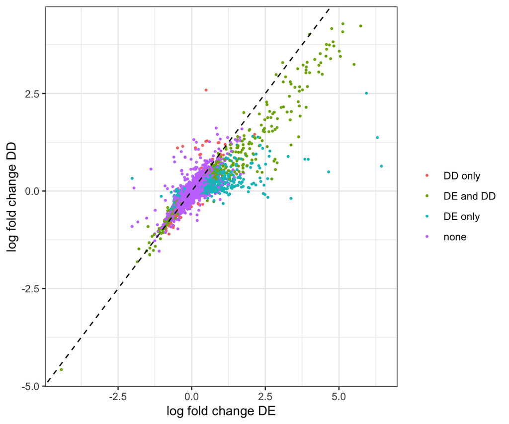

```r
ddGenes <- rownames(ddCrit)
ddPlot <- tibble(gene = ddGenes,
                 logFC_DE = deCrit$table[ddGenes, "logFC"],
                 logFC_DD = ddCrit$table$logFC,
                 DE = ddDe[ddGenes, "DE"] == 1,
                 DD = ddDe[ddGenes, "DD"] == 1) |>
  mutate(significant = case_when(DE & DD ~ "DE and DD", DE ~ "DE only",
                                 DD ~ "DD only", TRUE ~ "none"))
ggplot(ddPlot, aes(logFC_DE, logFC_DD, color = significant)) +
  geom_point(size = 0.5) +
  geom_abline(linetype = 2) +
  labs(x = "log fold change DE", y = "log fold change DD", color = "") +
  theme_bw()
```

- The screening stage finds 1359 genes. Of these, 793 are DE only, 90 DD only and 476 both DE and DD.
- With two hypotheses per gene, there is at most one true null hypothesis after a false screening hypothesis, so Shaffer’s procedure needs no correction in the confirmation stage (`method = "none"`).
- The DE and DD log fold changes are strongly correlated: most genes with a higher expression are also detected in more cells. The DD log fold changes are smaller, because the detection fraction cannot increase above 1.

**NoteComparison with Gilis et al. (2025)**

Gilis et al. (2025) analysed the same data with the same design, filtering and DD workflow, but with edgeR 3.40. We use edgeR 4, in which `glmQLFit` estimates the quasi-likelihood dispersions with a new method by default. With the settings of the paper (`estimateDisp` and `glmQLFit(..., robust = TRUE, legacy = TRUE)`, also for the DE analysis), we reproduce the numbers of the paper almost exactly: e.g. for the naive B cells of critical patients 1152 genes in the screening stage, of which 449 DD and 1122 DE (paper: 1149, 453 and 1125). With the default of edgeR 4, we find more genes, mainly more DD genes, but the conclusions are the same.

## 15. A gene that is DD but not DE (optional)

```r
ddOnly <- rownames(ddDe)[which(ddDe[, "DD"] == 1 & ddDe[, "DE"] == 0)]
ddOnly <- ddOnly[order(ddCrit$table[ddOnly, "PValue"])]
head(ddOnly, 20)
```

```
 [1] "IGHV3-49" "IGKV1D-8" "IFITM1"   "IGHV6-1"  "IGKV1-17" "CCDC191"
 [7] "IGHV1-24" "MCM5"     "IGLV6-57" "MDS2"     "MYC"      "SNX6"
[13] "S100A8"   "ZFP62"    "CAPN12"   "SYNC"     "RIN3"     "RNFT1"
[19] "TMEM191C" "KCNA3"
```

```r
# the first gene that is not an immunoglobulin variable gene
gene <- ddOnly[!grepl("^IG[HKL]V", ddOnly)][1]
gene
```

```
[1] "IFITM1"
```

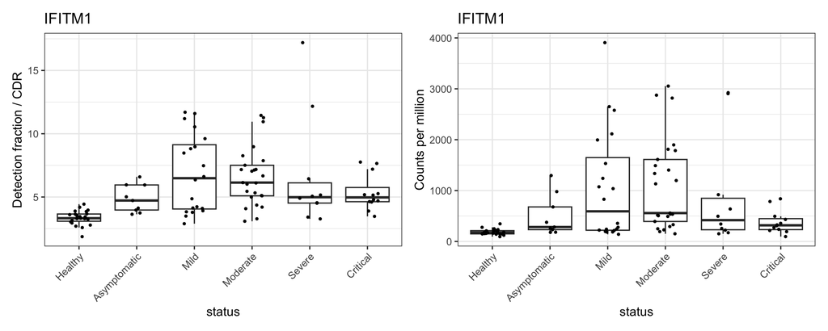

```r
donorIndex <- match(yNaive$samples$donor, pbNaive$donor)
geneData <- tibble(status = yNaive$samples$status,
                   detection = detection[gene, donorIndex] / cdr[donorIndex],
                   cpm = cpm(yNaive)[gene, ])
p1 <- ggplot(geneData, aes(status, detection)) +
  geom_boxplot(outlier.shape = NA) +
  geom_jitter(width = 0.2, size = 0.7) +
  labs(y = "Detection fraction / CDR", title = gene) +
  theme_bw() +
  theme(axis.text.x = element_text(angle = 45, hjust = 1))
p2 <- ggplot(geneData, aes(status, cpm)) +
  geom_boxplot(outlier.shape = NA) +
  geom_jitter(width = 0.2, size = 0.7) +
  labs(y = "Counts per million", title = gene) +
  theme_bw() +
  theme(axis.text.x = element_text(angle = 45, hjust = 1))
p1 + p2
```

We plot the detection fraction relative to the CDR of the donor, which is the quantity that the offset of the DD model corrects for.

- Several of the DD-only genes are immunoglobulin variable genes (*IGHV*, *IGKV*, *IGLV*). Each B cell expresses one heavy and one light chain V gene, at a high level. The detection of a V gene reflects the fraction of B cells that use it, i.e. the clonal composition of the B cells, while the average expression is dominated by the few cells that express it at a very high level.
- *IFITM1* is an interferon-stimulated gene. Its expression (CPM) is higher in all patient groups, but it is very variable between the patients: a few donors have a very high expression. For the critical patients, the DE test is therefore not significant. The detection fraction relative to the CDR is less sensitive to these donors with a very high expression in a few cells, and shows a consistent increase: here the DD analysis has more power than the DE analysis.
- In general, a gene that is DD but not DE is detected in a different fraction of the cells, while its average expression does not change significantly. This can point to a change in the distribution of the expression over the cells: e.g. a gene that is expressed at a high level in a few cells in one group and at a low level in many cells in the other group. The DD analysis can also have more power for lowly expressed genes, for which the counts are mostly zeros and ones and the detection contains most of the information.

## 16. All B cell types with muscat (optional)

`prepSCE` standardises the names of the cell type (`cluster_id`), sample (`sample_id`) and group (`group_id`) columns. `aggregateData` sums the counts (`fun = "sum"`) or the binarised counts (`fun = "num.detected"`) per cell type and donor, with one assay per cell type. The donor characteristics (site, sex) are kept in the `colData` of the pseudobulk object, so we can use the same design. The contrast matrix `L` of exercise 8 can be reused: only the names of the status coefficients change (`group_id` instead of `status`).

```r
library(muscat)
sceMuscat <- covid
sceMuscat$status <- relevel(droplevels(factor(sceMuscat$status)), ref = "Healthy")
sceMuscat <- prepSCE(sceMuscat, kid = "celltype", sid = "donor", gid = "status")
pbSum <- aggregateData(sceMuscat, assay = "counts", fun = "sum")
pbDet <- aggregateData(sceMuscat, assay = "counts", fun = "num.detected")
designMuscat <- model.matrix(~ site + sex + group_id, data = as.data.frame(colData(pbSum)))
LMuscat <- L
rownames(LMuscat) <- colnames(designMuscat)
LMuscat
```

```
                     Asymptomatic Mild Moderate Severe Critical Average
(Intercept)                     0    0        0      0        0     0.0
siteNcl                         0    0        0      0        0     0.0
sexmale                         0    0        0      0        0     0.0
group_idAsymptomatic            1    0        0      0        0     0.2
group_idMild                    0    1        0      0        0     0.2
group_idModerate                0    0        1      0        0     0.2
group_idSevere                  0    0        0      1        0     0.2
group_idCritical                0    0        0      0        1     0.2
```

```r
resDS <- pbDS(pbSum, design = designMuscat, contrast = LMuscat, min_cells = 20, verbose = FALSE)
resDD <- pbDD(pbDet, design = designMuscat, contrast = LMuscat, min_cells = 20, verbose = FALSE)
resStagewise <- stagewise_DS_DD(resDS, resDD)
```

The results are stored per contrast and per cell type. The number of DE and DD genes (FDR 5% within each cell type) for the comparison of the moderate patients with the healthy donors:

```r
sapply(names(resDS$table$Moderate), function(ct)
  c(DE = sum(resDS$table$Moderate[[ct]]$p_adj.loc < 0.05),
    DD = sum(resDD$table$Moderate[[ct]]$p_adj.loc < 0.05)))
```

```
   naive B cell immature B cell unswitched memory B cell
DE         2442             345                      132
DD         1578             121                      185
   class switched memory B cell B cell
DE                          332     10
DD                          242      6
```

We compare the results for the naive B cells with our own analysis of exercises 8 and 13:

```r
compareMuscat <- t(sapply(colnames(L), function(contrast) {
  ownDE <- tests[[contrast]]$table
  ownDD <- testsDD[[contrast]]$table
  mDE <- resDS$table[[contrast]][["naive B cell"]]
  mDD <- resDD$table[[contrast]][["naive B cell"]]
  genesDD <- intersect(rownames(ownDD), mDD$gene)
  c(DE_own = sum(p.adjust(ownDE$PValue, "BH") < 0.05),
    DE_muscat = sum(mDE$p_adj.loc < 0.05),
    DD_own = sum(p.adjust(ownDD$PValue, "BH") < 0.05),
    DD_muscat = sum(mDD$p_adj.loc < 0.05),
    DD_genes_own = nrow(ownDD),
    DD_genes_muscat = nrow(mDD),
    cor_pDD = cor(log10(ownDD[genesDD, "PValue"]), log10(mDD$p_val[match(genesDD, mDD$gene)])))
}))
round(compareMuscat, 3)
```

```
             DE_own DE_muscat DD_own DD_muscat DD_genes_own DD_genes_muscat
Asymptomatic      3         3      0         0         8693            8332
Mild            310       310    216       220         8693            8332
Moderate       2441      2442   1706      1578         8693            8332
Severe         1794      1795    646       543         8693            8332
Critical       1429      1430    359       280         8693            8332
Average        1979      1979    846       777         8693            8332
             cor_pDD
Asymptomatic       1
Mild               1
Moderate           1
Severe             1
Critical           1
Average            1
```

- The DE results are (almost) identical: `pbDS` uses the same filtering, TMM normalisation and edgeR QL pipeline as our own analysis.
- For DD, the p-values of the shared genes are identical (correlation 1): `pbDD` implements the same workflow, with the filter on the median detection fraction, the CDR offset and `poisson.bound = FALSE`.
- The numbers of DD genes differ because the analyses test different genes: `pbDD` filters the genes with `filterByExpr` on the number of detected cells, whereas we started from the genes that pass `filterByExpr` on the counts of the DE analysis. Here, muscat tests 8332 genes and our analysis 8693: some of the genes that only we test are DD.
- muscat analyses all B cell types in one call, and also reports p-values that are adjusted over all cell types together (`p_adj.glb`).
- `stagewise_DS_DD` combines the DE and DD results of each cell type with the stage-wise test of exercise 14.

# Differential abundance

## 17. Composition of the B cells (optional)

```r
abundances <- unclass(table(covid$celltype, droplevels(covid$donor)))
samplesDA <- donors[match(colnames(abundances), donors$donor), ]
samplesDA$status <- relevel(droplevels(samplesDA$status), ref = "Healthy")
yDA <- DGEList(abundances, samples = as.data.frame(samplesDA))
yDA <- normLibSizes(yDA)
designDA <- model.matrix(~ site + sex + status, data = yDA$samples)
fitDA <- glmQLFit(yDA, designDA)
testDA <- glmQLFTest(fitDA, coef = grep("status", colnames(designDA)))
topTags(testDA)$table |>
  knitr::kable(digits = 3)
```

|  | logFC.statusAsymptomatic | logFC.statusMild | logFC.statusModerate | logFC.statusSevere | logFC.statusCritical | logCPM | F | PValue | FDR |
| --- | --- | --- | --- | --- | --- | --- | --- | --- | --- |
| B cell | 0.397 | -0.244 | 1.143 | 0.404 | 0.762 | 15.576 | 6.690 | 0.000 | 0.000 |
| class switched memory B cell | -0.089 | -0.652 | -0.279 | 0.076 | -0.283 | 16.898 | 3.146 | 0.010 | 0.025 |
| unswitched memory B cell | -0.317 | -0.724 | -0.058 | -0.156 | -0.230 | 15.765 | 2.733 | 0.021 | 0.035 |
| immature B cell | -0.265 | -0.291 | -0.464 | -0.410 | -0.194 | 16.334 | 1.395 | 0.229 | 0.234 |
| naive B cell | 0.014 | 0.047 | -0.031 | 0.128 | 0.116 | 19.421 | 1.384 | 0.234 | 0.234 |

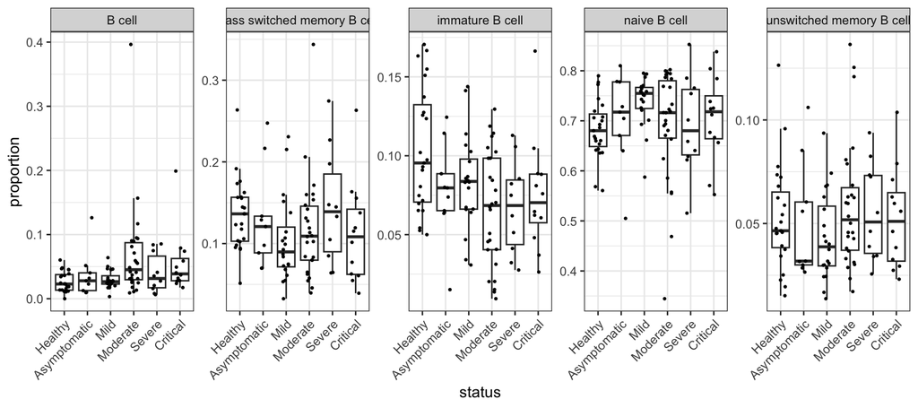

```r
as_tibble(as.data.frame(t(abundances) / colSums(abundances))) |>
  bind_cols(samplesDA) |>
  pivot_longer(levels(covid$celltype), names_to = "celltype", values_to = "proportion") |>
  ggplot(aes(status, proportion)) +
  geom_boxplot(outlier.shape = NA) +
  geom_jitter(width = 0.2, size = 0.5) +
  facet_wrap(~ celltype, scales = "free_y", nrow = 1) +
  theme_bw() +
  theme(axis.text.x = element_text(angle = 45, hjust = 1))
```

- The proportion of the other B cells (`B cell`) changes most with the disease status: it increases in the moderate and critical patients. The changes of the memory B cells are smaller.
- We use the same design as in the DE analysis, with the donor as experimental unit: the counts are the numbers of cells per cell type and donor, and the library size is the number of B cells of the donor.
- The TMM normalisation assumes that most cell types do not change in abundance. With only 5 cell types this is a strong assumption: a large change in the naive B cells, which are the majority of the B cells, changes the proportions of all other cell types. The model can only describe the composition within the B cells: we do not know the total number of PBMCs, so we cannot tell whether a cell type becomes more abundant in the blood.

## References

Gilis, Jeroen, Laura Perin, Milan Malfait, et al. 2025. “Differential Detection Workflows for Multi-Sample Single-Cell RNA-seq Data.” *BMC Genomics* 26: 886. https://doi.org/10.1186/s12864-025-12102-x.

Stephenson, Emily, Gary Reynolds, et al. 2021. “Single-Cell Multi-Omics Analysis of the Immune Response in COVID-19.” *Nature Medicine* 27 (5): 904–16. https://doi.org/10.1038/s41591-021-01329-2.